# FigureYa176BlandAltman

**Author(s)**: Xiaofan Lu  
**Reviewer(s)**: Ying Ge, Junyi Shen  
**Date**: 2025-12-03

## 1 Academic Citation

If you use this code in your work or research, we kindly request that you cite our publication:

Xiaofan Lu, et al. (2025). FigureYa: A Standardized Visualization Framework for Enhancing Biomedical Data Interpretation and Research Efficiency. iMetaMed. https://doi.org/10.1002/imm3.70005

## 2 需求描述 Requirement

作者用Bland-Altman的方法比较了自己建立的模型和传统的模型的一致性。网上找了下，好像没有可以重复这个的代码。

The author compared the consistency between the model he established and the traditional model using the Bland-Altman method. I searched online and it seems there’s no code that can repeat this.

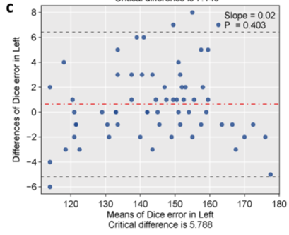

Fromhttps://www.sciencedirect.com/science/article/pii/S2352396420300992

Figure S1. Bland-Altman plots reveal consistency between the V-Net derived segmentation and the gold standard. The differences (y-axis) are plotted versus the average (x-axis) of two appraisers (i.e., the position of the plan-box in the testing set and gold standard) for pulmonary apex, basis, left and right boundary in Bland-Altman plot a) to d), respectively. Slopes are calculated by linear regression of differences on average and the corresponding statistical P values are provided for testing a constant difference based on a null hypothesis—the slope equals to 0. Critical difference is ‘two’ times standard deviation of differences, equals half the difference of lower and upper limit.

## 3 应用场景 Application Scenarios

Bland-Altman plot用于比较不同evaluation之间的agreement，并进行一致性(斜率)检验。

直观展示两种方法的差异模式和一致性程度，通过散点分布和置信区间判断一致性范围，斜率检验的P值帮助判断是否存在系统性偏差。

适合连续性变量，需要评估可替换性，想发现系统性偏差的情况；

不适合分类变量（阳性/阴性），只关心总体准确率，样本量太小（<30个）。

AI时代涌现大量新方法、新工具，需要跟传统方法比较。

这不是简单的准确率问题，需要发现AI的系统性偏差：例如AI在轻度病例上表现很好，但在重度病例上系统性地低估严重程度。这种模式在Bland-Altman图上一目了然。

如果AI和经典方法的系统性偏差超过临床可接受范围，即使AI准确率很高，也不能直接替换使用。

The Bland-Altman plot was used to compare the agreements among different evaluations and to conduct consistency (slope) tests.

It can be used to compare the agreement between different evaluations and to conduct consistency (slope) tests.

It is suitable for continuous variables, requires assessment of replaceability, and wants to find situations with systematic bias;

It is not suitable for categorical variables (positive/negative), only cares about overall accuracy, and the sample size is too small (<30).

There is a surge of new methods and tools in the AI era that need to be compared with traditional methods.

It is not a simple accuracy issue, but a need to find the systematic bias of AI: for example, AI performs well in mild cases, but systematically underestimates the severity in severe cases. This pattern is obvious in the Bland-Altman graph.

If the systematic bias between AI and classical methods exceeds the clinically acceptable range, AI cannot be directly replaced even if its accuracy is very high.

## 4 环境设置 Environment Setup

```r
source("install_dependencies.R")
```

```
## Starting R package installation...
## ===========================================
##
## Installing CRAN packages...
## Package already installed: BlandAltmanLeh
## Package already installed: MethComp
## Package already installed: smatr
##
## ===========================================
## Package installation completed!
## You can now run your R scripts in this directory.
```

```r
library(BlandAltmanLeh) # Bland-Altman相关函数 # Bland-Altman related functions
library(MethComp) # Bland-Altman相关函数 # Bland-Altman related functions
library(smatr) # 斜率检验相关函数 # Slope test related functions

Sys.setenv(LANGUAGE = "en") #显示英文报错信息 # Display an English error message
options(stringsAsFactors = FALSE) #禁止chr转成factor # prohibit chr from being converted to factor
```

自定义函数绘制BAplot并做斜率检验 A custom function is used to draw BAplot and perform slope tests

```r
BA.baseplot <- function(measurement1 = NULL, # 方法一的结果 # the result of Method one
                        measurement2 = NULL, # 方法二的结果 # the result of Method Two
                        slope.methed = c("OLS","SMA","MA"), # 选择一种斜率检验方法，一般为OLS # Select a slope test method, usually OLS
                        slope.test.value = 0, # 斜率检验值和0比较 # Compare the slope test value with 0
                        xlab = "Means", # BA图的横轴名 # BA the name of the horizontal axis of the graph
                        ylab = "Differences", # BA图的纵轴名 # BA the name of the vertical axis of the graph
                        main = "", # BA图的主题 # BA the theme of the diagram
                        point.color = NULL, # BA图离散点的颜色 # BA the color of discrete points in the graph
                        refline.color = NULL, # 参考线的颜色（金标准线）# The color of the reference line (gold standard line)
                        confline.color = NULL, # BA图置信区间的颜色 # BA the color of the confidence interval of the graph
                        fig.label = NULL, # 最终出图的名称 # the name of the final output image
                        width = 6, # 图像宽度 # image width
                        height = 5) { # 图像高度 # image height

  if(length(measurement1) != length(measurement2)) {stop("The length of measurements must be the same!\n")}
  if(!is.element(slope.methed,c("OLS","SMA","MA"))) {stop("The method for slope test must be one of OLS, SMA, MA!\n")}

  ba.stats <- bland.altman.stats(measurement1,measurement2) # 得到BA有关的统计量 # get ba related statistics

  meth <- ifelse(slope.methed == "OLS",0,
                 ifelse(slope.methed == "SMA",1,2))

  # 进行斜率检验
  # Conduct the slope test
  slope <- slope.test(y = ba.stats$diffs,
                      x = ba.stats$means,
                      test.value = slope.test.value,
                      method = meth) # 根据选择的斜率检验方法设置meth值  # Set the meth value according to the selected slope test method

  # 绘图
  # Drawing
  pdf(paste0("BAplot_",fig.label,".pdf"), width = width, height = height)
  par(bty="o", mgp = c(2,0.5,0), mar = c(4.1,4.1,2.1,2.1), tcl=-.25, font.main=3, las=1)
  par(xpd=F)

  # 设置坐标轴区间
  # Set the coordinate axis intervals
  if(range(ba.stats$diffs)[1] > ba.stats$lines[1]) {
    ylim1 <- ba.stats$lines[1] - ceiling(range(ba.stats$diffs)[2]-range(ba.stats$diffs)[1]/10)
  } else {ylim1 <- range(ba.stats$diffs)[1]}

  if(range(ba.stats$diffs)[2] < ba.stats$lines[3]) {
    ylim2 <- ba.stats$lines[3] + ceiling(range(ba.stats$diffs)[2]-range(ba.stats$diffs)[1]/10)
  } else {ylim2 <- range(ba.stats$diffs)[2]}

  # 设置空画布（第一次）
  # Set an Empty Canvas (First Time)
  plot(NULL, NULL,ylim = c(ylim1,ylim2),xlim = range(ba.stats$means),
       xlab = xlab,ylab = ylab,
       main = main,
       sub=paste("Critical difference is", round(ba.stats$critical.diff,3)),
       col="white",yaxt="n",xaxt="n")

  axis(side = 2,at = pretty(c(ylim1,ylim2)),labels = pretty(c(ylim1,ylim2)))
  axis(side = 1,at = pretty(ba.stats$means),labels = pretty(ba.stats$means))

  rect(par("usr")[1],par("usr")[3],par("usr")[2],par("usr")[4],col = "#EAE9E9",border = F) # 填充背景色（此时画布外缘黑线被遮盖） # fill the background color (the canvas covering the outer black line)
  grid(col = "white", lty = 1, lwd = 1.5) # 添加网格 # Add grid

  # 添加非金标准的结果（散点）
  # Add non-gold standard results (scattered points)
  points(ba.stats$means,
         ba.stats$diffs,
         col = ggplot2::alpha(point.color,0.8),
         pch = 19)

  # 添加置信区间
  # Add confidence intervals
  abline(h = ba.stats$lines,
         lty=c(2,4,2),
         lwd=c(1.5,2,1.5),
         col=c(confline.color,refline.color,confline.color))

  # 重新创建空画布（第二次）还原外侧线
  # Recreate an Empty canvas (Second Time) Restore the outer lines
  par(new = T, bty="o",xpd=F)
  plot(NULL, NULL,
       col = "white",
       xlim = range(ba.stats$means), ylim = range(ba.stats$diffs),
       xlab = "", ylab = "",
       xaxt = "n", yaxt = "n")

  # 添加斜率检验结果
  # Add the slope test result
  legend("topright",
         legend = paste0("Slope",ifelse(slope$b < 0.001," < 0.001",paste0(" = ",round(slope$b,3))),"\nP ",
                         ifelse(slope$p < 0.001," < 0.001",paste0(" = ",round(slope$p,3)))),
         border=NA,bty = "n", y.intersp=1,cex = 0.9)

  # 关闭图像句柄
  # Close the image handle
  invisible(dev.off())
}
```

## 5 输入文件 Input File

easy_input.csv，第一列error，第二列为分组信息，这里是测试结果和金标准结果。

easy_input.csv, the first column is error and the second column is grouping information. Here are the test results and the gold standard results.

```r
dat <- read.table("easy_input.txt", sep = "\t", row.names = NULL, header = T, check.names = F, stringsAsFactors = F)
head(dat)
```

```
##   error dataset
## 1   121    TEST
## 2   142    TEST
## 3   166    TEST
## 4   166    TEST
## 5   142    TEST
## 6   121    TEST
```

```r
table(dat$dataset)
```

```
##
##   GT TEST
##   63   63
```

## 6 分析并画图 Analyze and Draw Diagrams

调用前面的自定义函数，检验和画图一步到位。

By calling the previous custom function, verification and drawing can be accomplished in one step.

```r
# 测试结果
# Test Results
test <- abs(dat[which(dat$dataset == "TEST"),"error"])

# 金标准结果
# Gold Standard Results
gt <- abs(dat[which(dat$dataset == "GT"),"error"])

BA.baseplot(measurement1 = test, # 测试方法的结果 # test method result
            measurement2 = gt, # 金标准结果  # Gold Standard result
            slope.methed = "OLS", # 斜率方法选择OLS # select OLS for the slope method
            xlab = "Means of Dice error in Left", # 添加x轴名 # add the X-axis name
            ylab = "Differences of Dice error in Left", # 添加y轴名 # add the name of the Y-axis
            point.color = "#224A8D", # 散点颜色  # scatter color
            refline.color = "#E53435", # 参考线颜色 # reference line color
            confline.color = "grey30", # 置信线颜色 # confidence line color
            fig.label = "example") # 输出文件名  # Output file name
```

[figure not shown]